# Actividades de Regresion y Modelos Estacionarios

Nombre: **Alejandro Patron Montero**

## Ejercicio 1

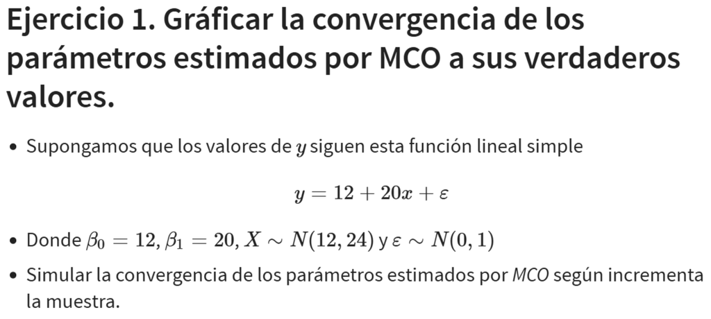

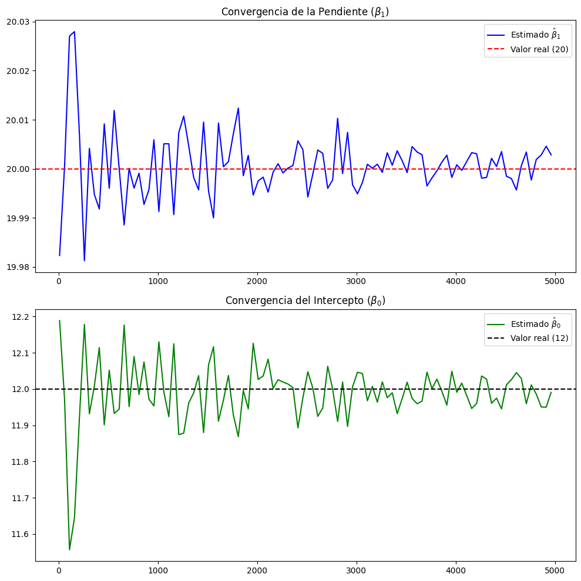

```python
import matplotlib.pyplot as plt
import numpy as np

# 1. Valores reales (nuestra meta)
beta0_real = 12
beta1_real = 20

tamanios_n = np.arange(10, 5000, 50)
estimaciones_beta1 = []
estimaciones_beta0 = [] # Nueva lista para el intercepto

# 2. Simulación
for n in tamanios_n:
    # Generamos los datos ficticios
    x = np.random.normal(12, np.sqrt(24), n)
    error = np.random.normal(0, 1, n)
    y = beta0_real + beta1_real * x + error

    # --- Cálculo de Beta 1 (Pendiente) ---
    beta1_hat = np.cov(x, y)[0, 1] / np.var(x, ddof=1)
    estimaciones_beta1.append(beta1_hat)

    # --- Cálculo de Beta 0 (Intercepto) ---
    # Usamos la fórmula: beta0 = promedio(y) - beta1 * promedio(x)
    beta0_hat = np.mean(y) - beta1_hat * np.mean(x)
    estimaciones_beta0.append(beta0_hat)

# 3. Graficamos ambos resultados
fig, (ax1, ax2) = plt.subplots(2, 1, figsize=(10, 10))

# Gráfica para Beta 1
ax1.plot(tamanios_n, estimaciones_beta1, label='Estimado $\hat{\\beta}_1$', color='blue')
ax1.axhline(y=beta1_real, color='r', linestyle='--', label='Valor real (20)')
ax1.set_title('Convergencia de la Pendiente ($\\beta_1$)')
ax1.legend()

# Gráfica para Beta 0
ax2.plot(tamanios_n, estimaciones_beta0, label='Estimado $\hat{\\beta}_0$', color='green')
ax2.axhline(y=beta0_real, color='black', linestyle='--', label='Valor real (12)')
ax2.set_title('Convergencia del Intercepto ($\\beta_0$)')
ax2.legend()

plt.tight_layout()
plt.show()
```

## Ejercicio 2

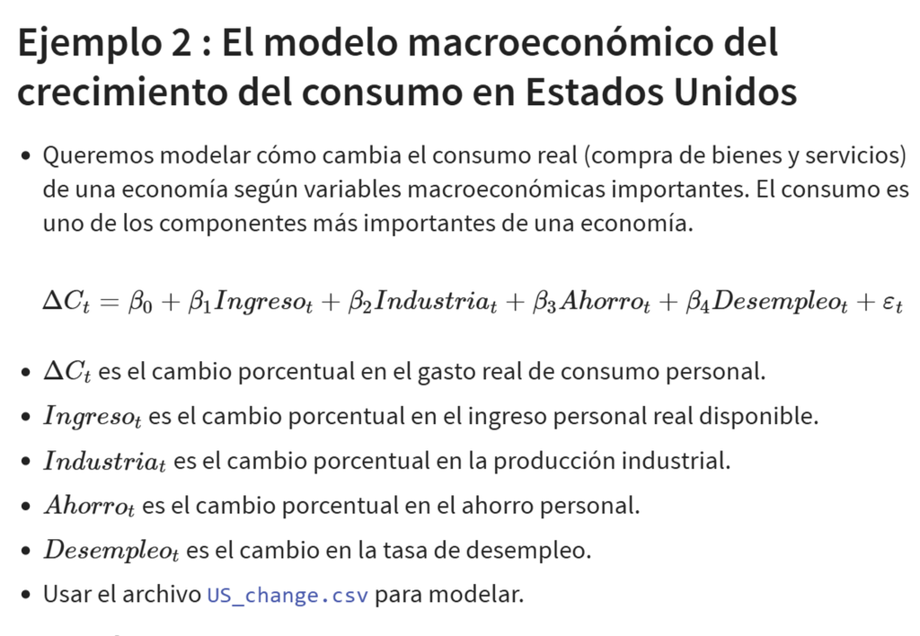

```python
import pandas as pd
import numpy as np

data = pd.read_csv("data/US_change.csv")
data.head(5)
```

|  | ds | y | Income | Production | Savings | Unemployment | unique_id |
| --- | --- | --- | --- | --- | --- | --- | --- |
| 0 | 1970-01-01 | 0.618566 | 1.044801 | -2.452486 | 5.299014 | 0.9 | US_change |
| 1 | 1970-04-01 | 0.451984 | 1.225647 | -0.551459 | 7.789894 | 0.5 | US_change |
| 2 | 1970-07-01 | 0.872872 | 1.585154 | -0.358652 | 7.403984 | 0.5 | US_change |
| 3 | 1970-10-01 | -0.271848 | -0.239545 | -2.185691 | 1.169898 | 0.7 | US_change |
| 4 | 1971-01-01 | 1.901345 | 1.975925 | 1.909764 | 3.535667 | -0.1 | US_change |

```python
data.info()
```

```
<class 'pandas.DataFrame'>
RangeIndex: 198 entries, 0 to 197
Data columns (total 7 columns):
 #   Column        Non-Null Count  Dtype
---  ------        --------------  -----
 0   ds            198 non-null    str
 1   y             198 non-null    float64
 2   Income        198 non-null    float64
 3   Production    198 non-null    float64
 4   Savings       198 non-null    float64
 5   Unemployment  198 non-null    float64
 6   unique_id     198 non-null    str
dtypes: float64(5), str(2)
memory usage: 11.0 KB
```

```python
# 1. Selección de variables según tu fórmula
# ΔCt = β0 + β1*Ingreso + β2*Industria + β3*Ahorro + β4*Desempleo
y = data['y']  # Cambio en Consumo
X = data[['Income', 'Production', 'Savings', 'Unemployment']]
```

```python
import statsmodels.api as sm
X = sm.add_constant(X)

modelo_macro = sm.OLS(y, X).fit()

print(modelo_macro.summary())
```

```
                            OLS Regression Results
==============================================================================
Dep. Variable:                      y   R-squared:                       0.768
Model:                            OLS   Adj. R-squared:                  0.763
Method:                 Least Squares   F-statistic:                     160.0
Date:                Sun, 15 Feb 2026   Prob (F-statistic):           3.93e-60
Time:                        12:07:42   Log-Likelihood:                -46.660
No. Observations:                 198   AIC:                             103.3
Df Residuals:                     193   BIC:                             119.8
Df Model:                           4
Covariance Type:            nonrobust
================================================================================
                   coef    std err          t      P>|t|      [0.025      0.975]
--------------------------------------------------------------------------------
const            0.2531      0.034      7.343      0.000       0.185       0.321
Income           0.7406      0.040     18.461      0.000       0.661       0.820
Production       0.0472      0.023      2.038      0.043       0.002       0.093
Savings         -0.0529      0.003    -18.088      0.000      -0.059      -0.047
Unemployment    -0.1747      0.096     -1.829      0.069      -0.363       0.014
==============================================================================
Omnibus:                       19.961   Durbin-Watson:                   2.218
Prob(Omnibus):                  0.000   Jarque-Bera (JB):               35.767
Skew:                           0.525   Prob(JB):                     1.71e-08
Kurtosis:                       4.798   Cond. No.                         53.6
==============================================================================

Notes:
[1] Standard Errors assume that the covariance matrix of the errors is correctly specified.
```

## Ejercicio 3

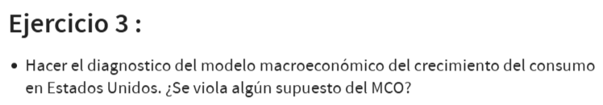

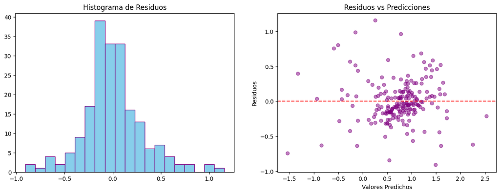

```
{'Jarque-Bera': np.float64(35.766829118006164), 'Chi^2 p-value': np.float64(1.7113220234569697e-08), 'Skew': np.float64(0.5249415925270943), 'Kurtosis': np.float64(4.798087462879785)}
```

```python
import scipy.stats as stats

residuos = modelo_macro.resid

fig, (ax1,ax2) = plt.subplots(1,2,figsize=(15,5))
ax1.hist(residuos,bins=20,edgecolor="purple",color="skyblue")
ax1.set_title('Histograma de Residuos')

#Residuos vs Valores Ajustados para verificar Homocedasticidad
ax2.scatter(modelo_macro.fittedvalues, residuos, color='purple', alpha=0.5)
ax2.axhline(y=0, color='r', linestyle='--')
ax2.set_xlabel('Valores Predichos')
ax2.set_ylabel('Residuos')
ax2.set_title('Residuos vs Predicciones')

plt.show()

#Prueba formal de normalidad (Jarque-Bera)
name = ['Jarque-Bera', 'Chi^2 p-value', 'Skew', 'Kurtosis']
test = sm.stats.jarque_bera(residuos)
print(dict(zip(name, test)))
```

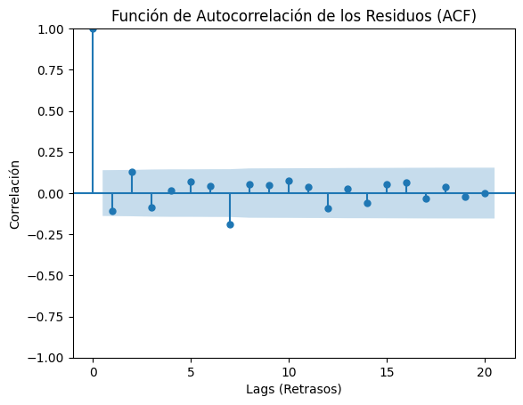

```python
import statsmodels.api as sm
from statsmodels.graphics.tsaplots import plot_acf

residuos = modelo_macro.resid

# Crear el gráfico de autocorrelación
plt.figure(figsize=(10, 5))
plot_acf(residuos, lags=20) # Analizamos los últimos 20 trimestres
plt.title('Función de Autocorrelación de los Residuos (ACF)')
plt.xlabel('Lags (Retrasos)')
plt.ylabel('Correlación')
plt.show()
```

## Ejercicio 5

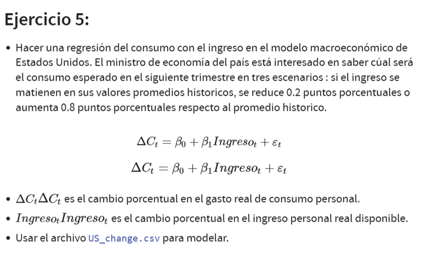

Aplicando Predictores Temporales (Tendencia y Dummies)

```python
# Agregar tendencia
data['trend'] = range(len(data))

# Agregar dummies estacionales (asumiendo que 'ds' es fecha)
data['ds'] = pd.to_datetime(data['ds'])
data['quarter'] = data['ds'].dt.quarter
dummies = pd.get_dummies(data['quarter'], prefix='Q', drop_first=True) # drop_first evita colinealidad

# Unir al dataframe original
df_final = pd.concat([data, dummies], axis=1)
df_final.head(5)
```

|  | ds | y | Income | Production | Savings | Unemployment | unique_id | trend | quarter | Q_2 | Q_3 | Q_4 |
| --- | --- | --- | --- | --- | --- | --- | --- | --- | --- | --- | --- | --- |
| 0 | 1970-01-01 | 0.618566 | 1.044801 | -2.452486 | 5.299014 | 0.9 | US_change | 0 | 1 | False | False | False |
| 1 | 1970-04-01 | 0.451984 | 1.225647 | -0.551459 | 7.789894 | 0.5 | US_change | 1 | 2 | True | False | False |
| 2 | 1970-07-01 | 0.872872 | 1.585154 | -0.358652 | 7.403984 | 0.5 | US_change | 2 | 3 | False | True | False |
| 3 | 1970-10-01 | -0.271848 | -0.239545 | -2.185691 | 1.169898 | 0.7 | US_change | 3 | 4 | False | False | True |
| 4 | 1971-01-01 | 1.901345 | 1.975925 | 1.909764 | 3.535667 | -0.1 | US_change | 4 | 1 | False | False | False |

Escenarios de Consumo Esperado: El ministro de economía quiere predecir el cambio en el consumo ($\Delta C_t$) basándose únicamente en el Ingreso. El modelo a estimar es:

$$\Delta C_t = \beta_0 + \beta_1 \text{Ingreso}_t + \epsilon_t$$

```python
import statsmodels.api as sm

y = df_final['y']
X_simple = sm.add_constant(df_final['Income'])
modelo_simple = sm.OLS(y, X_simple).fit()

beta0 = modelo_simple.params['const']
beta1 = modelo_simple.params['Income']
promedio_ingreso = df_final['Income'].mean()
```

```python
#Calcular los escenarios solicitados
# Escenario 1: El ingreso se mantiene en su promedio
escenario_1 = beta0 + beta1 * (promedio_ingreso)

# Escenario 2: El ingreso se reduce 0.2 puntos respecto al promedio
escenario_2 = beta0 + beta1 * (promedio_ingreso - 0.2)

# Escenario 3: El ingreso aumenta 0.8 puntos respecto al promedio
escenario_3 = beta0 + beta1 * (promedio_ingreso + 0.8)

#Mostrar resultados al "Ministro"
print(f"Promedio Histórico del Ingreso: {promedio_ingreso:.4f}%")
print("-" * 30)
print(f"Consumo Esperado (Escenario 1 - Promedio): {escenario_1:.4f}%")
print(f"Consumo Esperado (Escenario 2 - Reducción 0.2): {escenario_2:.4f}%")
print(f"Consumo Esperado (Escenario 3 - Aumento 0.8): {escenario_3:.4f}%")
```

```
Promedio Histórico del Ingreso: 0.7282%
------------------------------
Consumo Esperado (Escenario 1 - Promedio): 0.7425%
Consumo Esperado (Escenario 2 - Reducción 0.2): 0.6881%
Consumo Esperado (Escenario 3 - Aumento 0.8): 0.9599%
```

## Ejercicio 6

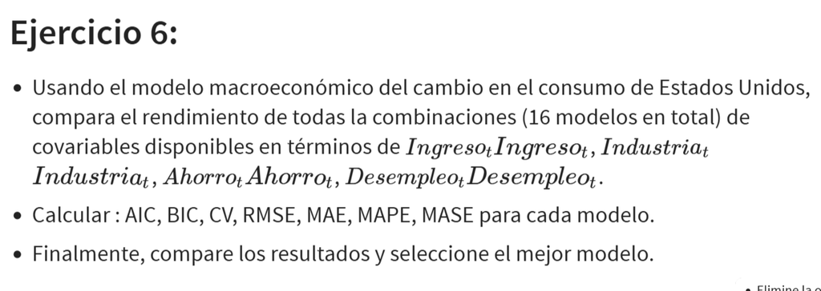

# Diagnóstico y Selección de Modelos: Evaluación de Rendimiento

En el análisis de regresión para series de tiempo, la selección del mejor modelo no solo depende de qué tan bien se ajusta a los datos pasados, sino de su capacidad de generalización y simplicidad.

## 1. Métricas de Selección (Complejidad vs. Ajuste)

Estas métricas penalizan la inclusión de variables innecesarias para evitar el sobreajuste (*overfitting*). **En ambos casos, el modelo con el valor más bajo es el preferido.**

### A. Criterio de Información de Akaike (AIC)

Permite comparar modelos equilibrando la bondad de ajuste con la complejidad. $$AIC = T \log\left(\frac{SSE}{T}\right) + 2(k + 2)$$ *Donde $T$ es el número de observaciones y $k$ el número de covariables.*

### B. Criterio Bayesiano de Información (BIC)

Similar al AIC, pero aplica una penalización más severa por cada variable extra ($k$) añadida, especialmente en muestras grandes. $$BIC = T \log\left(\frac{SSE}{T}\right) + (k + 2) \log(T)$$

## 2. Métricas de Precisión (Rendimiento del Pronóstico)

### Principales indicadores de error:

- **MAE (Mean Absolute Error):** El error absoluto promedio en las unidades originales de la variable. $$MAE = \text{mean}(|e_t|)$$
- **RMSE (Root Mean Squared Error):** La raíz del error cuadrático medio. Tiende a penalizar más los errores grandes (valores atípicos). $$RMSE = \sqrt{\text{mean}(e_t^2)}$$
- **MAPE (Mean Absolute Percentage Error):** Expresa el error en términos porcentuales, facilitando la interpretación económica. $$MAPE = \text{mean}\left(\left|100 \frac{e_t}{y_t}\right|\right)$$
- **MASE (Mean Absolute Scaled Error):** Útil para comparar la precisión entre diferentes series de tiempo al escalar el error según el método ingenuo (*naive*). $$MASE = \text{mean}(|q_j|)$$

```python
import itertools
import pandas as pd
import numpy as np
import statsmodels.api as sm

# 1. Definir variables
y = data['y']
features = ['Income', 'Production', 'Savings', 'Unemployment']
results = []

# 2. Generar todas las combinaciones (1 a 4 variables)
for r in range(1, 5):
    for combo in itertools.combinations(features, r):
        X = sm.add_constant(data[list(combo)])

        # Ajuste del modelo
        model = sm.OLS(y, X).fit()

        # Guardar métricas principales
        results.append({
            'Modelo': ' + '.join(combo),
            'AIC': model.aic,
            'BIC': model.bic,
            'R2_Adj': model.rsquared_adj,
            'RMSE': np.sqrt(model.mse_resid)
        })

# 3. Mostrar tabla comparativa ordenada por AIC
df_comparativa = pd.DataFrame(results).sort_values('AIC')
df_comparativa
```

|  | Modelo | AIC | BIC | R2_Adj | RMSE |
| --- | --- | --- | --- | --- | --- |
| 14 | Income + Production + Savings + Unemployment | 103.319799 | 119.761134 | 0.763481 | 0.310214 |
| 10 | Income + Production + Savings | 104.722150 | 117.875218 | 0.760621 | 0.312083 |
| 12 | Income + Savings + Unemployment | 105.537266 | 118.690334 | 0.759634 | 0.312726 |
| 5 | Income + Savings | 124.182562 | 134.047363 | 0.734586 | 0.328616 |
| 11 | Income + Production + Unemployment | 297.625779 | 310.778847 | 0.365836 | 0.507958 |
| 13 | Production + Savings + Unemployment | 302.761265 | 315.914333 | 0.349173 | 0.514589 |
| 6 | Income + Unemployment | 303.049317 | 312.914118 | 0.344985 | 0.516242 |
| 4 | Income + Production | 305.738892 | 315.603693 | 0.336027 | 0.519760 |
| 7 | Production + Savings | 309.220527 | 319.085328 | 0.324248 | 0.524350 |
| 9 | Savings + Unemployment | 313.008582 | 322.873384 | 0.311195 | 0.529390 |
| 8 | Production + Unemployment | 313.824760 | 323.689561 | 0.308350 | 0.530482 |
| 1 | Production | 321.798015 | 328.374549 | 0.276331 | 0.542622 |
| 3 | Unemployment | 322.513193 | 329.089727 | 0.273712 | 0.543603 |
| 0 | Income | 355.307114 | 361.883648 | 0.142885 | 0.590537 |
| 2 | Savings | 373.353321 | 379.929855 | 0.061095 | 0.618071 |

Siendo el mejor el modelo 14